# InSituTree hierarchical cell typing

Claire Williams

2024-12-12

## Overview

The `InSituTree` package is a small package that builds on [`InSituType`](https://github.com/Nanostring-Biostats/InSituType/tree/main) and provides a specialized application for its use. With this approach, you can perform supervised cell typing in a hierarchical manner – first making broad cell type assignments and then making progressively finer classifications.

## Installation

```r
# Install from github
devtools::install_github(
  "https://github.com/Nanostring-Biostats/CosMx-Analysis-Scratch-Space",
  subdir = "_code/InSituTree")
```

## Data preparation

SMI dataset of non small cell lung cancer (nsclc) that is included with the `InSituType` package.

```r
library(InSituType)
library(InSituTree)

# Basic dataset
data(mini_nsclc)
str(mini_nsclc)
```

```
#> List of 5
#>  $ counts: num [1:2198, 1:960] 0 0 0 0 0 0 0 0 0 0 ...
#>   ..- attr(*, "dimnames")=List of 2
#>   .. ..$ : chr [1:2198] "c_3_18_2" "c_3_18_3" "c_3_18_4" "c_3_18_5" ...
#>   .. ..$ : chr [1:960] "AATK" "ABL1" "ABL2" "ACE" ...
#>  $ neg   : num [1:2198, 1:20] 0 0 0 0 0 0 0 0 0 0 ...
#>   ..- attr(*, "dimnames")=List of 2
#>   .. ..$ : chr [1:2198] "c_3_18_2" "c_3_18_3" "c_3_18_4" "c_3_18_5" ...
#>   .. ..$ : chr [1:20] "NegPrb3" "NegPrb6" "NegPrb15" "NegPrb18" ...
#>  $ x     : num [1:2198] 7.34 7.4 7.42 7.46 7.53 ...
#>  $ y     : num [1:2198] -6.5 -6.5 -6.5 -6.5 -6.5 ...
#>  $ umap  : num [1:2198, 1:2] 1.489 -0.774 -1.915 1.927 1.135 ...
#>   ..- attr(*, "dimnames")=List of 2
#>   .. ..$ : chr [1:2198] "c_3_18_2" "c_3_18_3" "c_3_18_4" "c_3_18_5" ...
#>   .. ..$ : NULL
```

```r
# Cell type reference profile
data(ioprofiles)
str(ioprofiles)
```

```
#>  num [1:27161, 1:16] 2.10e+01 4.59e-04 2.13e-02 4.59e-04 4.15e-03 ...
#>  - attr(*, "dimnames")=List of 2
#>   ..$ : chr [1:27161] "FAM138A" "OR4F5" "RNU6-1100P" "AC114498.1" ...
#>   ..$ : chr [1:16] "B-cell" "endothelial" "fibroblast" "macrophage" ...
```

## Necessary inputs

Here we show the format of each of the necessary inputs to run `InSituTree`. Many of these mirror inputs for `InSituType`, and more information can be found in that package.

1. `x`: A matrix of counts data, cells x genes

```r
counts <- mini_nsclc$counts
str(counts)
```

```
#>  num [1:2198, 1:960] 0 0 0 0 0 0 0 0 0 0 ...
#>  - attr(*, "dimnames")=List of 2
#>   ..$ : chr [1:2198] "c_3_18_2" "c_3_18_3" "c_3_18_4" "c_3_18_5" ...
#>   ..$ : chr [1:960] "AATK" "ABL1" "ABL2" "ACE" ...
```

```r
counts[5:10, 10:15]
```

```
#>           ACTG2 ACVR1 ACVR1B ACVR2A ACVRL1 ADGRA2
#> c_3_18_6      0     0      0      0      0      0
#> c_3_18_7      0     0      0      0      0      0
#> c_3_18_10     0     0      0      0      0      0
#> c_3_18_11     0     0      0      0      0      0
#> c_3_18_12     0     0      1      0      1      0
#> c_3_18_19     0     0      0      0      0      0
```

2. `neg`: A vector giving each cell’s mean negative control value:

```r
negmean <- Matrix::rowMeans(mini_nsclc$neg)
head(negmean)
```

```
#> c_3_18_2 c_3_18_3 c_3_18_4 c_3_18_5 c_3_18_6 c_3_18_7
#>     0.00     0.00     0.00     0.05     0.00     0.00
```

3. `full_profiles`: Reference profile giving the expected expression profile of each cell subtype, with genes in rows and cell subtypes in columns. Major cell types are not needed. The reference matrix must be linear-scale, not log-scale. Genes (rows) do not need to be aligned to the counts matrix. For more information about generating a reference profile, see [here](https://nanostring-biostats.github.io/CosMx-Analysis-Scratch-Space/posts/hybrid-reference-profiles/).

```r
str(ioprofiles)
```

```
#>  num [1:27161, 1:16] 2.10e+01 4.59e-04 2.13e-02 4.59e-04 4.15e-03 ...
#>  - attr(*, "dimnames")=List of 2
#>   ..$ : chr [1:27161] "FAM138A" "OR4F5" "RNU6-1100P" "AC114498.1" ...
#>   ..$ : chr [1:16] "B-cell" "endothelial" "fibroblast" "macrophage" ...
```

```r
ioprofiles[1:5, ]
```

```
#>                  B-cell endothelial fibroblast macrophage mast          mDC
#> FAM138A    2.096034e+01           0          0          0    0 1.390347e+01
#> OR4F5      4.585635e-04           0          0          0    0 4.959941e-04
#> RNU6-1100P 2.131342e-02           0          0          0    0 3.364625e-02
#> AC114498.1 4.585635e-04           0          0          0    0 4.959941e-04
#> RNU6-1199P 4.145011e-03           0          0          0    0 4.959941e-04
#>                monocyte   neutrophil           NK          pDC  plasmablast
#> FAM138A    1.525272e+01  47.51214042 13.700490052 14.709188917 11.922652363
#> OR4F5      5.048288e-04   0.00107558  0.000374971  0.000468242  0.001279865
#> RNU6-1100P 2.395197e+01 333.72730875  0.000374971  0.028842730  0.432247095
#> AC114498.1 5.048288e-04   0.00107558  0.000374971  0.000468242  0.001279865
#> RNU6-1199P 5.048288e-04   0.00107558  0.000374971  0.007623073  0.001279865
#>            T CD4 memory  T CD4 naive T CD8 memory  T CD8 naive         Treg
#> FAM138A    1.494321e+01 1.122716e+01 5.3871876931 0.9259157510 1.354705e+01
#> OR4F5      4.071673e-04 4.089748e-04 0.0004038248 0.0004066689 3.847774e-04
#> RNU6-1100P 4.514122e-02 3.990783e-03 0.0203505401 0.0031968972 1.260998e-01
#> AC114498.1 6.060066e-04 4.089748e-04 0.0019765979 0.0004066689 3.847774e-04
#> RNU6-1199P 1.520570e-03 4.089748e-04 0.0010411853 0.0004066689 1.938572e-02
```

4. `cth`: A nested list of the **c**ell **t**yping **h**ierarchy. Here we set up one that groups the immune cells into multiple subclusters. Any single-child nodes will be treated as endpoints. Endpoints can be named or unnamed; see “NK” for an example of an endpoint that is unnamed.

```r
celltype_hierarchy_list <- list(
  "structural" = c(
    "endothelial",
    "fibroblast"
  ),
  "myeloid" = c(
    "macrophage",
    "mast",
    "mDC",
    "monocyte",
    "neutrophil"
  ),
  "lymphoid" = list(
    "B-lymphoid" = c(
      "B-cell",
      "pDC",
      "plasmablast"
    ),
    "T-lymphoid" = list(
      "T4" = c(
        "T CD4 memory",
        "T CD4 naive",
        "Treg"
      ),
      "T8" = c(
        "T CD8 memory",
        "T CD8 naive"
      ),
      "NK"
    )
  )
)
```

5. `name_for_new_annotation`: A character name for the new annotations. This will appear as the name for the top level cell typing results and is used in a recursive function call. Recommendation is to leave at the default value of “topLevel”.

```r
annotation_names <- "topLevel"
```

## Optional inputs

The remaining inputs to `InSituTree` are optional, with some having default values.

6. `bg`: Expected background, optional. This is the non-zero expected detection rate of background in the `counts` data, typically set to `NULL` to be automatically derived from the relationship between the `neg` vector and the `counts` matrix. One can derive it with the `estimateBackground()` function from the `InSituType` package.

```r
background <- NULL

## Not used, for demonstration
#bg_example <- c("c_3_18_2" = 0.00278, "c_3_18_3" = 0.00437", "c_3_18_4" = 0.01431 . . . )
```

7. `cohort`: A vector of cohorts provides a grouping of cells based on alternative, non-RNA, data types, such as immunofluorescent staining, cell shape metrics, tissue structures, etc. One way to generate these cohorts is to use the `fastCohorting()` function in the `InSituType` package and include any variables that might be informative for cell typing, *except* variables you’ll want to analyze later. For example, if you’ll later perform differential expression as a function of spatial context, then it’s safer to exclude spatial context from the cell typing exercise (and therefore from this function). In this small example we will not use cohorts, but it is generally recommended. The random vector below is provided to give an example of the expected structure. See the `InSituType` package for more information about how to generate cohorts with the `fastCohorting()` function.

```r
# These will not be used in this vignette and should not be random.
# This is an example to show the structure.
set.seed(2024)
example_cohorts <- sample(1:30, size = ncol(counts), replace = TRUE)
```

8. `excluded_genes`: A character vector of genes to exclude from the cell typing. For example, these may be genes with a strong platform effect between the query dataset and reference profiles. Default is `NULL`.

```r
genes_to_exclude <- c("MALAT1")
```

9. `quantile_absolute_expression_difference_param`: A lower quantile limit for gene selection based on absolute difference in expression between the cell type with the highest expression and that with the lowest expression among all cell types considered for a given branch. Value should be between 0 and 1; default is 0.5.

```r
quantile_abs_difference <- 0.5

# For reference, the absolute differences in expression
# for a set of six genes across the whole ioprofile are:
diffs <- sapply(c("CD3D", "CD3E", "JCHAIN", "KRT18", "VIM", "MALAT1"),
                function(gene) {
                  diff(range(ioprofiles[gene, ]))
                })
diffs
```

```
#>        CD3D        CD3E      JCHAIN       KRT18         VIM      MALAT1
#>   1243.0416   2353.2094 301705.8527    108.1911  18024.1937  59850.4078
```

```r
# The 50% quantile is:
quantile(diffs, 0.5)
```

```
#>     50%
#> 10188.7
```

```r
# Genes satisfying the expression criteria for absolute difference,
# ie. genes with expression difference bigger than the 50% of all genes'
# expression differences, if only six were considered:
names(diffs)[diffs > quantile(diffs, quantile_abs_difference, na.rm = TRUE)]
```

```
#> [1] "JCHAIN" "VIM"    "MALAT1"
```

10. `quantile_percent_expression_difference_param`: A lower quantile limit for gene selection based on percentage difference in expression between the cell type with the highest expression and that with the lowest expression among all cell types considered for a given branch. Value should be between 0 and 1; default is 0.5.

```r
quantile_perc_difference <- 0.5

# For reference, the percent differences in expression
# for a set of six genes across the whole ioprofile are:
percs <- sapply(c("CD3D", "CD3E", "JCHAIN", "KRT18", "VIM", "MALAT1"),
                function(gene) {
                  diff(range(ioprofiles[gene, ])) / max(ioprofiles[gene, ])
                })
percs
```

```
#>      CD3D      CD3E    JCHAIN     KRT18       VIM    MALAT1
#> 1.0000000 0.9998957 0.9999837 0.9924013 0.9540667 0.8778193
```

```r
# The 50% quantile is:
quantile(percs, 0.5)
```

```
#>       50%
#> 0.9961485
```

```r
# Genes satisfying the expression criteria for percentage difference,
# ie. genes with expression difference bigger than the 50% of all genes'
# percentage expression differences, if only six were considered:
names(percs)[percs > quantile(percs, quantile_perc_difference, na.rm = TRUE)]
```

```
#> [1] "CD3D"   "CD3E"   "JCHAIN"
```

```r
# Genes passing both of the above filters
genes_to_use <- intersect(names(diffs)[
  diffs > quantile(diffs, quantile_abs_difference, na.rm = TRUE)],
  names(percs)[
    percs > quantile(percs, quantile_perc_difference, na.rm = TRUE)])

genes_to_use
```

```
#> [1] "JCHAIN"
```

The only gene passing **both** of the above filters is JCHAIN, and so in this small example where we’re considering all cell types together and only six genes, only this gene would be considered as having high differentiating power at the given granularity level. Note that when fewer cell types or subtypes are considered simultaneously, we expect to see more variability in the `diffs` and `percs`.

11. `return_summary_annotation`: A logical value indicating whether to return the final summary annotation. This data frame shows the annotation that has been made for each cell at each level of the annotation tree. Recommendation is to keep this at its default value of `TRUE`.

```r
return_summary_df <- TRUE
```

## Tree-style cell typing

First, we can print a simple structured list to visualize the cell type hierarchy we’ve laid out with our cell type hierarchy list.

```r
printTree(celltype_hierarchy_list, prefix = "|-")
```

```
#> |- structural
#>   |- endothelial
#>   |- fibroblast
#> |- myeloid
#>   |- macrophage
#>   |- mast
#>   |- mDC
#>   |- monocyte
#>   |- neutrophil
#> |- lymphoid
#>   |- B-lymphoid
#>     |- B-cell
#>     |- pDC
#>     |- plasmablast
#>   |- T-lymphoid
#>     |- T4
#>       |- T CD4 memory
#>       |- T CD4 naive
#>       |- Treg
#>     |- T8
#>       |- T CD8 memory
#>       |- T CD8 naive
#>     |- NK
```

Once we’ve verified that this tree shows the hierarchy and cell type relationships that we’d expect, we can run supervised nested cell typing.

```r
res <- runInSituTree(
  x = counts,
  neg = negmean,
  bg = background,
  full_profiles = ioprofiles,
  cth = celltype_hierarchy_list,
  name_for_new_annotation = annotation_names,
  cohort = NULL,
  excluded_genes = genes_to_exclude,
  quantile_absolute_expression_difference_param = quantile_abs_difference,
  quantile_percent_expression_difference_param = quantile_perc_difference,
  return_summary_annotation = return_summary_df
)
```

[output not shown]

[output cut: 282 more lines]

```
#> Summarizing group: lymphoid
#> B-cell & plasmablast & pDC
#> Summarizing group: B-lymphoid
#> Completed summarizing group: B-lymphoid
#> T8 & T4 & NK
#> Summarizing group: T-lymphoid
#> T CD4 memory & Treg
#> Summarizing group: T4
#> Completed summarizing group: T4
#> T CD8 memory
#> Summarizing group: T8
#> Completed summarizing group: T8
#> Completed summarizing group: T-lymphoid
#> Completed summarizing group: lymphoid
#> Completed summarizing group: topLevel
```

In the messages that print out, we see that a handful of cells are removed from cell typing if they have zero counts in any of the gene subsets used for typing.

## Review results

The results from running `InSituTree` contain two main components:

1. Nested list of results from each run of `InSituTypeML`
2. Summary of annotations at each level of the tree

The nested results list contains the typical outputs of `InSituType` for each round of cell typing, and one additional metric, `ctsPerCell`, which is the counts of the selected genes for each cell at the given round of subclustering. This counts metric could be used to evaluate the confidence of a particular round of subclustering, since cell type assignments for low-count cells are likely to be less confident. Each level of the results list contains:

- `result`: The `InSituType` results plus counts per cell for the *current* level of cell typing.
- `subclusterings`: A nested list of clustering results for the next level down of annotations.
- `name`: The node name of the current level of cell typing.

As an example, we look at the assignment of structural cells to fibroblast or endothelial and use the flightpath tool from `InSituType` to visualize how well cells were assigned to these major types.

```r
names(res)
```

```
#> [1] "topLevel"          "summaryAnnotation"
```

```r
names(res[["topLevel"]])
```

```
#> [1] "result"         "subclusterings" "name"
```

```r
str(res[["topLevel"]]$result)
```

```
#> List of 7
#>  $ clust                      : Named chr [1:2196] "myeloid" "myeloid" "myeloid" "myeloid" ...
#>   ..- attr(*, "names")= chr [1:2196] "c_3_18_2" "c_3_18_3" "c_3_18_4" "c_3_18_5" ...
#>  $ prob                       : Named num [1:2196] 1 1 1 1 1 ...
#>   ..- attr(*, "names")= chr [1:2196] "c_3_18_2" "c_3_18_3" "c_3_18_4" "c_3_18_5" ...
#>  $ profiles                   : num [1:244, 1:3] 0.14246 0.02394 0.08838 0.07112 0.00437 ...
#>   ..- attr(*, "dimnames")=List of 2
#>   .. ..$ : chr [1:244] "ACKR1" "ACTG2" "ACVRL1" "ADGRF5" ...
#>   .. ..$ : chr [1:3] "structural" "myeloid" "lymphoid"
#>  $ sds                        : NULL
#>  $ logliks                    : num [1:2196, 1:3] -47.6 -58.4 -168.9 -60.1 -80.2 ...
#>   ..- attr(*, "dimnames")=List of 2
#>   .. ..$ : chr [1:2196] "c_3_18_2" "c_3_18_3" "c_3_18_4" "c_3_18_5" ...
#>   .. ..$ : chr [1:3] "structural" "myeloid" "lymphoid"
#>  $ logliks_from_lost_celltypes: num [1:2196, 1] -Inf -Inf -Inf -Inf -Inf ...
#>   ..- attr(*, "dimnames")=List of 2
#>   .. ..$ : chr [1:2196] "c_3_18_2" "c_3_18_3" "c_3_18_4" "c_3_18_5" ...
#>   .. ..$ : chr "undefined"
#>  $ ctsPerCell                 : Named num [1:2198] 7 10 33 10 44 12 31 29 59 41 ...
#>   ..- attr(*, "names")= chr [1:2198] "c_3_18_2" "c_3_18_3" "c_3_18_4" "c_3_18_5" ...
```

```r
str(res[["topLevel"]]$subclusterings)
```

```
#> List of 3
#>  $ structural:List of 3
#>   ..$ result        :List of 7
#>   .. ..$ clust                      : Named chr [1:869] "endothelial" "endothelial" "endothelial" "endothelial" ...
#>   .. .. ..- attr(*, "names")= chr [1:869] "c_3_18_6" "c_3_18_10" "c_3_18_12" "c_3_18_20" ...
#>   .. ..$ prob                       : Named num [1:869] 1 1 0.901 1 1 ...
#>   .. .. ..- attr(*, "names")= chr [1:869] "c_3_18_6" "c_3_18_10" "c_3_18_12" "c_3_18_20" ...
#>   .. ..$ profiles                   : num [1:257, 1:2] 0.0214 0.2039 0.0214 0.0627 0.0266 ...
#>   .. .. ..- attr(*, "dimnames")=List of 2
#>   .. .. .. ..$ : chr [1:257] "ACE" "ACKR1" "ACKR3" "ACTA2" ...
#>   .. .. .. ..$ : chr [1:2] "endothelial" "fibroblast"
#>   .. ..$ sds                        : NULL
#>   .. ..$ logliks                    : num [1:869, 1:2] -206 -224 -162 -190 -417 ...
#>   .. .. ..- attr(*, "dimnames")=List of 2
#>   .. .. .. ..$ : chr [1:869] "c_3_18_6" "c_3_18_10" "c_3_18_12" "c_3_18_20" ...
#>   .. .. .. ..$ : chr [1:2] "endothelial" "fibroblast"
#>   .. ..$ logliks_from_lost_celltypes: num [1:869, 1] -Inf -Inf -Inf -Inf -Inf ...
#>   .. .. ..- attr(*, "dimnames")=List of 2
#>   .. .. .. ..$ : chr [1:869] "c_3_18_6" "c_3_18_10" "c_3_18_12" "c_3_18_20" ...
#>   .. .. .. ..$ : chr "undefined"
#>   .. ..$ ctsPerCell                 : Named num [1:869] 68 57 46 43 121 4 20 25 15 25 ...
#>   .. .. ..- attr(*, "names")= chr [1:869] "c_3_18_6" "c_3_18_10" "c_3_18_12" "c_3_18_20" ...
#>   ..$ subclusterings: list()
#>   ..$ name          : chr "structural"
#>  $ myeloid   :List of 3
#>   ..$ result        :List of 7
#>   .. ..$ clust                      : Named chr [1:1050] "macrophage" "macrophage" "macrophage" "macrophage" ...
#>   .. .. ..- attr(*, "names")= chr [1:1050] "c_3_18_2" "c_3_18_3" "c_3_18_4" "c_3_18_5" ...
#>   .. ..$ prob                       : Named num [1:1050] 0.794 0.95 1 0.741 0.988 ...
#>   .. .. ..- attr(*, "names")= chr [1:1050] "c_3_18_2" "c_3_18_3" "c_3_18_4" "c_3_18_5" ...
#>   .. ..$ profiles                   : num [1:166, 1:5] 0.0315 0.024 0.024 0 0 ...
#>   .. .. ..- attr(*, "dimnames")=List of 2
#>   .. .. .. ..$ : chr [1:166] "ABL2" "ACE" "ACVRL1" "ADGRG3" ...
#>   .. .. .. ..$ : chr [1:5] "macrophage" "mast" "mDC" "monocyte" ...
#>   .. ..$ sds                        : NULL
#>   .. ..$ logliks                    : num [1:1050, 1:5] -10.3 -29.8 -80.7 -29.1 -36.2 ...
#>   .. .. ..- attr(*, "dimnames")=List of 2
#>   .. .. .. ..$ : chr [1:1050] "c_3_18_2" "c_3_18_3" "c_3_18_4" "c_3_18_5" ...
#>   .. .. .. ..$ : chr [1:5] "macrophage" "mast" "mDC" "monocyte" ...
#>   .. ..$ logliks_from_lost_celltypes: num [1:1050, 1] -Inf -Inf -Inf -Inf -Inf ...
```

[output cut: 107 more lines]

```
#>   .. .. .. .. .. ..$ sds                        : NULL
#>   .. .. .. .. .. ..$ logliks                    : num [1:14, 1] -163.7 -105 -43.5 -109.5 -94.1 ...
#>   .. .. .. .. .. .. ..- attr(*, "dimnames")=List of 2
#>   .. .. .. .. .. .. .. ..$ : chr [1:14] "c_3_18_107" "c_3_18_442" "c_3_18_747" "c_3_18_879" ...
#>   .. .. .. .. .. .. .. ..$ : chr "T CD8 memory"
#>   .. .. .. .. .. ..$ logliks_from_lost_celltypes: num [1:14, 1:2] -200.8 -128.6 -52.9 -146.4 -119.3 ...
#>   .. .. .. .. .. .. ..- attr(*, "dimnames")=List of 2
#>   .. .. .. .. .. .. .. ..$ : chr [1:14] "c_3_18_107" "c_3_18_442" "c_3_18_747" "c_3_18_879" ...
#>   .. .. .. .. .. .. .. ..$ : chr [1:2] "T CD8 naive" "undefined"
#>   .. .. .. .. .. ..$ ctsPerCell                 : Named num [1:14] 30 25 9 32 26 12 7 20 48 23 ...
#>   .. .. .. .. .. .. ..- attr(*, "names")= chr [1:14] "c_3_18_107" "c_3_18_442" "c_3_18_747" "c_3_18_879" ...
#>   .. .. .. .. ..$ subclusterings: list()
#>   .. .. .. .. ..$ name          : chr "T8"
#>   .. .. ..$ name          : chr "T-lymphoid"
#>   ..$ name          : chr "lymphoid"
```

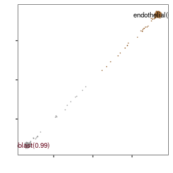

```r
InSituType::flightpath_plot(
  insitutype_result =
    res[["topLevel"]]$subclusterings[["structural"]]$result)
```

The summary annotation data frame shows the cell type assigned at each level of annotation, as well as the posterior probability for each assignment. Any final cell types, found as endpoints in the cell type hierarchy, are cascaded right to further annotation levels. For example, cells assigned to ‘endothelial’ at annotation level 2 in this example will also be labeled as ‘endothelial’ for annotation levels 3 and 4. In other words, the the right most `annotLevel` will contain the final cluster assignment at the finest level.

Note that any cells which did not have any counts in the genes used for subclustering will not get a cell type assignment; if this happens in the first round of annotation, these cells will show `NA` for all annotation levels. If this happens at later rounds of annotation, the last assignment will be cascaded right. One such example is shown in the results below

```r
first_NAcell <- min(which(is.na(res$summaryAnnotation$annotLevel_1)))
res$summaryAnnotation[c(1:5, first_NAcell), ]
```

```
#>             annotLevel_1 probs_annotLevel_1 annotLevel_2 probs_annotLevel_2
#> c_3_18_2         myeloid          1.0000000   macrophage          0.7939587
#> c_3_18_3         myeloid          1.0000000   macrophage          0.9500811
#> c_3_18_4         myeloid          1.0000000   macrophage          1.0000000
#> c_3_18_5         myeloid          0.9999942   macrophage          0.7407833
#> c_3_18_6      structural          1.0000000  endothelial          1.0000000
#> c_3_18_1006         <NA>                 NA         <NA>                 NA
#>             annotLevel_3 probs_annotLevel_3 annotLevel_4 probs_annotLevel_4
#> c_3_18_2      macrophage          0.7939587   macrophage          0.7939587
#> c_3_18_3      macrophage          0.9500811   macrophage          0.9500811
#> c_3_18_4      macrophage          1.0000000   macrophage          1.0000000
#> c_3_18_5      macrophage          0.7407833   macrophage          0.7407833
#> c_3_18_6     endothelial          1.0000000  endothelial          1.0000000
#> c_3_18_1006         <NA>                 NA         <NA>                 NA
```